# LSTM Mean-Variance Portfolio Optimization

## MATH 5430 spr23

### Project 2

### Group H

- Bierdel, Aime - ab4884
- Mavani, Dhyey - ddm2149
- Schmidle, Daniel - dps2150
- Ter-Avanesov, Boris- bt2522

## Contents

- 1 Data
  - Extract
  - Transform
  - NA Check
- 2 Model Pipes
  - 2.1 LSTM Base
  - 2.2 LSTM + GRU
  - 2.3 LSTM + GRU + ATTENTION
  - 2.4 LSTM + CNN
- 3 MVP Portfolio optimization
- 4 Results
  - MODELS
  - Final Results

```python
# setup
import pandas as pd
import yfinance as yf
import datetime
```

# 1 Data

The data used in this study was collected from Yahoo Finance through the yfinance API for the 10year period of 5/6/2013 to 5/2/2023. The chosen universe consists of ['GOOGL', 'AAPL', 'MSFT', 'DIS', 'WBD', 'V', 'JNJ', 'PG', 'AMZN', 'UNH', 'HD', 'CVX'].

## Extract

```python
tickers = ['GOOGL', 'AAPL', 'MSFT', 'DIS', 'WBD', 'V', 'JNJ', 'PG', 'AMZN', 'UNH', 'HD', 'CVX']
#fixed 10y period
start_date = datetime.datetime(2013, 5, 6)
end_date = datetime.datetime(2023, 5, 2)

data = yf.download(tickers = tickers,
            #period = "10y",
            start = start_date,
            end = end_date,
            interval = "1wk",
            prepost = False,
            repair = True)

data = data['Close']
```

```
[*********************100%***********************]  12 of 12 completed
```

```python
data.head()
```

| Date | AAPL | AMZN | CVX | DIS | GOOGL | HD | JNJ | MSFT | PG | UNH | V | WBD |
| --- | --- | --- | --- | --- | --- | --- | --- | --- | --- | --- | --- | --- |
| 2013-05-06 | 16.177500 | 13.1815 | 123.230003 | 67.199997 | 22.027779 | 76.010002 | 85.760002 | 32.689999 | 78.760002 | 62.910000 | 44.687500 | 40.204395 |
| 2013-05-13 | 15.473571 | 13.4950 | 123.419998 | 66.580002 | 22.752253 | 76.860001 | 88.089996 | 34.869999 | 80.019997 | 62.840000 | 46.142502 | 40.291264 |
| 2013-05-20 | 15.898214 | 13.0870 | 125.449997 | 65.489998 | 21.854855 | 78.989998 | 86.820000 | 34.270000 | 81.879997 | 62.060001 | 45.112499 | 40.638733 |
| 2013-05-27 | 16.061787 | 13.4600 | 122.750000 | 63.080002 | 21.802301 | 78.660004 | 84.180000 | 34.900002 | 76.760002 | 62.630001 | 44.535000 | 40.301483 |
| 2013-06-03 | 15.778929 | 13.8435 | 121.699997 | 64.849998 | 22.015265 | 78.739998 | 84.910004 | 35.669998 | 77.750000 | 62.570000 | 44.985001 | 39.034237 |

## Transform

- train test split

```python
# train test split
split_idx = int(len(data) * 0.8)
train_df = data.iloc[:split_idx]
remaining_df = data.iloc[split_idx:]
split_idx_2 = int(len(remaining_df) * 0.5)
validation_df = remaining_df.iloc[:split_idx_2+1]
test_df = remaining_df.iloc[split_idx_2+1:]
```

```python
print(f'train dates: {min(train_df.index).strftime("%Y-%m-%d")} to {max(train_df.index).strftime("%Y-%m-%d")}')
print(f'validation dates: {min(validation_df.index).strftime("%Y-%m-%d")} to {max(validation_df.index).strftime("%Y-%m-%d")}')
print(f'test dates: {min(test_df.index).strftime("%Y-%m-%d")} to {max(test_df.index).strftime("%Y-%m-%d")}')
# 10 year period - 8 train, 1 test, 1 validation
```

```
train dates: 2013-05-06 to 2021-04-26
validation dates: 2021-05-03 to 2022-05-02
test dates: 2022-05-09 to 2023-05-01
```

## NA Check

```python
#checking if there are missing values
data.isna().value_counts()
```

```
AAPL   AMZN   CVX    DIS    GOOGL  HD     JNJ    MSFT   PG     UNH    V      WBD
False  False  False  False  False  False  False  False  False  False  False  False    522
dtype: int64
```

no missing values found

# 2 Model Pipes

- 2.1 LSTM Base
- 2.2 LSTM + GRU
- 2.3 LSTM + GRU + ATTENTION
- 2.4 LSTM + CNN

## 2.1 LSTM Base

```python
# LSTM setup
from sklearn.preprocessing import MinMaxScaler
import numpy as np
import tensorflow.keras
from tensorflow.keras.models import Sequential
from tensorflow.keras.layers import Dense, LSTM, Dropout, SpatialDropout1D
from tensorflow.keras.callbacks import EarlyStopping
from sklearn.base import BaseEstimator, TransformerMixin
from keras import regularizers
```

```python
# LSTM with some modifications but no CNN or bidirectional
# Normalize the input features
class CustomMinMaxScaler(BaseEstimator, TransformerMixin):
     def __init__(self, feature_range=(0, 1)):
         self.feature_range = feature_range

     def fit(self, X, y=None):
         data_min = np.nanmin(X, axis=0)
         data_max = np.nanmax(X, axis=0)
         self.scale_ = (self.feature_range[1] - self.feature_range[0]) / (data_max - data_min)
         self.scale_[data_max == data_min] = 1.0
         self.min_ = self.feature_range[0] - data_min * self.scale_
         return self

     def transform(self, X):
         return X * self.scale_ + self.min_

     def inverse_transform(self, X):
         return (X - self.min_) / self.scale_


# Combine the data frames into one data frame
combined_df = pd.concat([train_df, test_df, validation_df], axis=0)

# Scale the combined data set
scaler = CustomMinMaxScaler(feature_range=(0, 1))
combined_df_sc = scaler.fit_transform(combined_df)
combined_df_sc.head()

# Split the scaled data back into train, test, and validation data sets
train_df_sc = combined_df_sc[:len(train_df)]
test_df_sc = combined_df_sc[len(train_df):len(train_df)+len(test_df)]
validation_df_sc = combined_df_sc[len(train_df)+len(test_df):]

# Create new DataFrames with the scaled data and original column names
train_df_sc = pd.DataFrame(train_df_sc, columns=train_df.columns, index=train_df.index)
test_df_sc = pd.DataFrame(test_df_sc, columns=test_df.columns, index=test_df.index)
validation_df_sc = pd.DataFrame(validation_df_sc, columns=validation_df.columns, index=validation_df.index)

def create_dataset(X, y, time_steps=1):
    Xs, ys = [], []
    for i in range(len(X) - time_steps + 1):
        Xs.append(X[i:i+time_steps])
        ys.append(y[i+time_steps-1])
    return np.array(Xs), np.array(ys)

# Set the time steps for LSTM
time_steps = 52
```

```python
# scaling works...
train_df_sc.head()
```

| Date | AAPL | AMZN | CVX | DIS | GOOGL | HD | JNJ | MSFT | PG | UNH | V | WBD |
| --- | --- | --- | --- | --- | --- | --- | --- | --- | --- | --- | --- | --- |
| 2013-05-06 | 0.012195 | 0.000547 | 0.502400 | 0.046725 | 0.006530 | 0.009659 | 0.025835 | 0.004937 | 0.108659 | 0.001738 | 0.006829 | 0.455718 |
| 2013-05-13 | 0.007936 | 0.002360 | 0.503895 | 0.042177 | 0.012202 | 0.012139 | 0.049349 | 0.011925 | 0.121900 | 0.001595 | 0.013901 | 0.456994 |
| 2013-05-20 | 0.010505 | 0.000000 | 0.519871 | 0.034182 | 0.005176 | 0.018354 | 0.036532 | 0.010001 | 0.141446 | 0.000000 | 0.008895 | 0.462096 |
| 2013-05-27 | 0.011495 | 0.002158 | 0.498623 | 0.016504 | 0.004765 | 0.017391 | 0.009890 | 0.012021 | 0.087642 | 0.001165 | 0.006088 | 0.457144 |
| 2013-06-03 | 0.009784 | 0.004376 | 0.490360 | 0.029487 | 0.006432 | 0.017625 | 0.017257 | 0.014489 | 0.098045 | 0.001043 | 0.008275 | 0.438535 |

```python
forecasts = {}
verbose = 0

for ticker in train_df.columns:
    if ticker == 'SPY':
        continue
    print(f"Processing {ticker}...")
    # Get the index of the ticker column
    ticker_idx = list(train_df.columns).index(ticker)

    # Drop the ticker column from the DataFrames
    train_data_X = train_df_sc.drop(columns=[ticker])
    train_data_Y = train_df_sc[ticker]
    test_data_X = test_df_sc.drop(columns=[ticker])
    test_data_Y = test_df_sc[ticker]
    validation_data_X = validation_df_sc.drop(columns=[ticker])
    validation_data_Y = validation_df_sc[ticker]

    # Reshape the input data to 3D array (samples, time_steps, features)
    X_train, y_train = create_dataset(pd.DataFrame(train_data_X), train_data_Y, time_steps)
    X_test, y_test = create_dataset(pd.DataFrame(test_data_X), test_data_Y, time_steps)

    # Define the LSTM model architecture
    model = Sequential()
    model.add(LSTM(64, activation='tanh', recurrent_activation = 'selu',kernel_initializer="glorot_uniform",
    recurrent_initializer="orthogonal", activity_regularizer = regularizers.l1_l2(0.000001, 0.000005), return_sequences = True, input_shape=(X_train.shape[1], X_train.shape[2])))
    model.add(SpatialDropout1D(0.15))
    model.add(Dense(1))

    # Compile the LSTM model
    model.compile(optimizer='adam', loss='mae', run_eagerly=True)

    # Define the early stopping callback
    early_stopping = EarlyStopping(monitor='val_loss', patience=4, restore_best_weights=True)

    X_val, y_val = create_dataset(pd.DataFrame(validation_data_X), validation_data_Y, time_steps)

    # Train the model
    history = model.fit(X_train, y_train, epochs=100, batch_size=20, validation_data=(X_val, y_val), verbose=verbose, shuffle=False, callbacks=[early_stopping])

    # Make predictions
    test_data_X = test_data_X.values.reshape((test_data_X.shape[0]//(time_steps), time_steps, test_data_X.shape[1]))
    y_pred = model.predict(test_data_X)
    forecasts[ticker] = scaler.inverse_transform(y_pred)
```

```
Processing AAPL...
Processing AMZN...
Processing CVX...
Processing DIS...
Processing GOOGL...
Processing HD...
Processing JNJ...
Processing MSFT...
Processing PG...
Processing UNH...
Processing V...
Processing WBD...
```

```python
print(f"Number of keys in the dictionary: {len(forecasts)}")
print(f"List of keys: {list(forecasts.keys())}")
for key in forecasts:
    print(key, forecasts[key].shape)

# For each series we have 52 (weekly) forecasts [13 is total number of series including explanatory ones and the target]
```

```
Number of keys in the dictionary: 12
List of keys: ['AAPL', 'AMZN', 'CVX', 'DIS', 'GOOGL', 'HD', 'JNJ', 'MSFT', 'PG', 'UNH', 'V', 'WBD']
AAPL (1, 52, 12)
AMZN (1, 52, 12)
CVX (1, 52, 12)
DIS (1, 52, 12)
GOOGL (1, 52, 12)
HD (1, 52, 12)
JNJ (1, 52, 12)
MSFT (1, 52, 12)
PG (1, 52, 12)
UNH (1, 52, 12)
V (1, 52, 12)
WBD (1, 52, 12)
```

```python
import matplotlib.pyplot as plt
from sklearn.metrics import mean_absolute_percentage_error
```

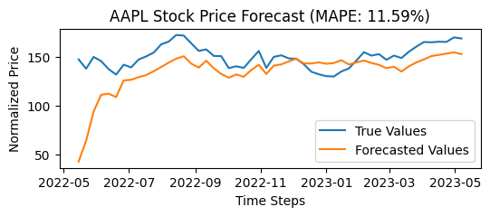

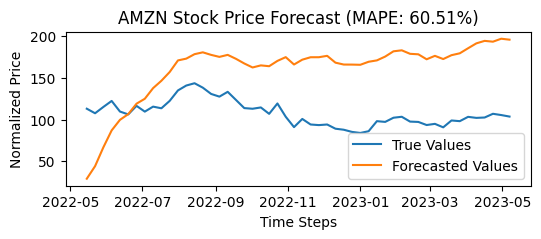

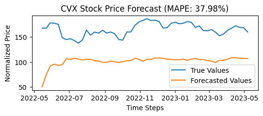

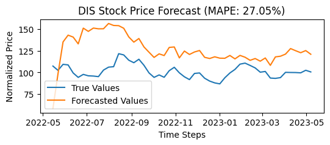

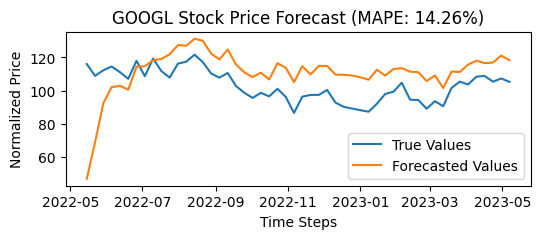

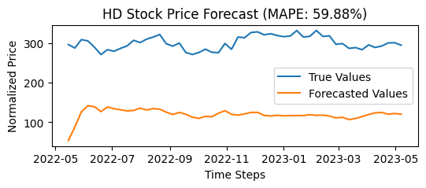

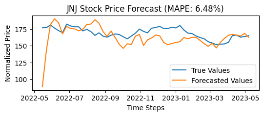

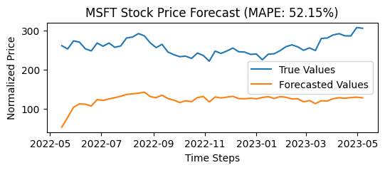

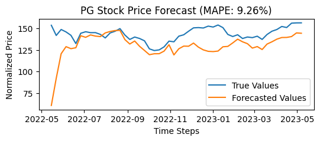

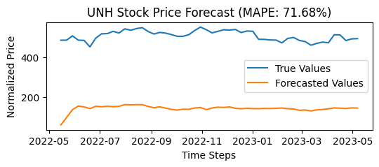

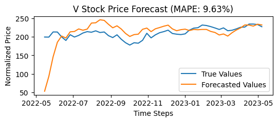

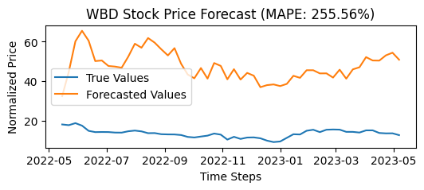

```python
# Define the start and end dates of the test data
start_date = test_df.index[0]
end_date = test_df.index[-1]

# Extend the date range
new_end_date = end_date + pd.DateOffset(weeks=1) # Extend by 1
date_range = pd.date_range(start=start_date, end=new_end_date, freq='W')

# Loop through the dictionary and extract the forecasts for each series
for key in forecasts:
    # Extract the forecasted values for the current series
    forecast_values = forecasts[key][0, :, 0].flatten()
    # Extract the true values for the current series
    true_values = test_df[key]
    # Calculate the MAPE for the current series
    mape = mean_absolute_percentage_error(true_values, forecast_values)

    # Plot the forecasted values against the true values for the current series
    plt.figure(figsize=(6, 2))
    plt.plot(date_range, true_values, label='True Values')
    plt.plot(date_range, forecast_values, label='Forecasted Values')
    plt.title(f'{key} Stock Price Forecast (MAPE: {100*mape:.2f}%)')
    plt.xlabel('Time Steps')
    plt.ylabel('Normalized Price')
    plt.legend()
    plt.show()
```

## 2.2 LSTM + GRU

Stacked Recurrent Neural Network (RNN) model consisting of Long Short-Term Memory (LSTM) and Gated Recurrent Unit (GRU) layers, along with a Spatial Dropout layer and a Dense output layer

```python
from tensorflow.keras.layers import GRU, Bidirectional, TimeDistributed
```

```python
forecasts_2 = {}
#print ouput of training epochs or not
verbose = 0

for ticker in train_df.columns:
    if ticker == 'SPY':
        continue
    print(f"Processing {ticker}...")
    # Get the index of the ticker column
    ticker_idx = list(train_df.columns).index(ticker)

    # Drop the ticker column from the DataFrames
    train_data_X = train_df_sc.drop(columns=[ticker])
    train_data_Y = train_df_sc[ticker]
    test_data_X = test_df_sc.drop(columns=[ticker])
    test_data_Y = test_df_sc[ticker]
    validation_data_X = validation_df_sc.drop(columns=[ticker])
    validation_data_Y = validation_df_sc[ticker]

    # Reshape the input data to 3D array (samples, time_steps, features)
    X_train, y_train = create_dataset(pd.DataFrame(train_data_X), train_data_Y, time_steps)
    X_test, y_test = create_dataset(pd.DataFrame(test_data_X), test_data_Y, time_steps)

    # Define the LSTM model architecture
    model = Sequential()
    model.add(LSTM(84, activation='tanh', recurrent_activation = 'selu', kernel_initializer="glorot_uniform",
    recurrent_initializer="orthogonal", recurrent_dropout = 0.05, return_sequences = True, input_shape=(X_train.shape[1], X_train.shape[2])))
    model.add(Bidirectional(GRU(64, activation='tanh', return_sequences = True, input_shape=(X_train.shape[1], X_train.shape[2]))))
    model.add(SpatialDropout1D(0.15))
    model.add(Dense(1))

    # Compile the LSTM model
    model.compile(optimizer='adam', loss='mae', run_eagerly=True)

    # Define the early stopping callback
    early_stopping = EarlyStopping(monitor='val_loss', patience=4, restore_best_weights=True)

    X_val, y_val = create_dataset(pd.DataFrame(validation_data_X), validation_data_Y, time_steps)

    # Train the model
    history = model.fit(X_train, y_train, epochs=100, batch_size=20, validation_data=(X_val, y_val), verbose=verbose, shuffle=False, callbacks=[early_stopping])

    # Make predictions
    test_data_X = test_data_X.values.reshape((test_data_X.shape[0]//(time_steps), time_steps, test_data_X.shape[1]))
    y_pred = model.predict(test_data_X)
    forecasts_2[ticker] = scaler.inverse_transform(y_pred)
```

```
Processing AAPL...
Processing AMZN...
Processing CVX...
Processing DIS...
Processing GOOGL...
Processing HD...
Processing JNJ...
Processing MSFT...
Processing PG...
Processing UNH...
Processing V...
Processing WBD...
```

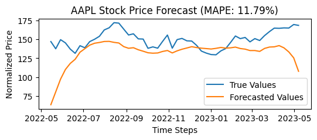

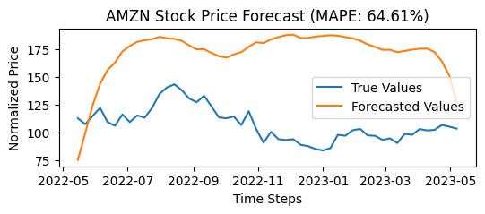

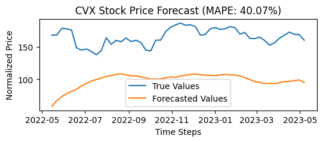

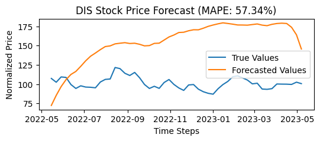

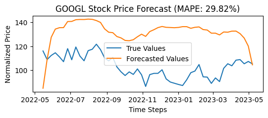

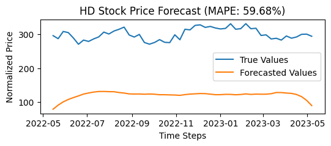

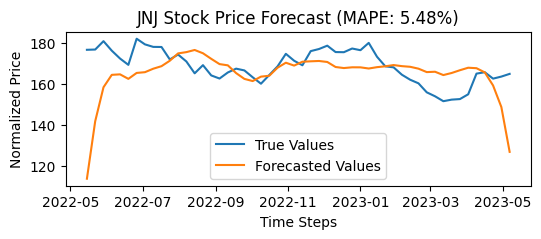

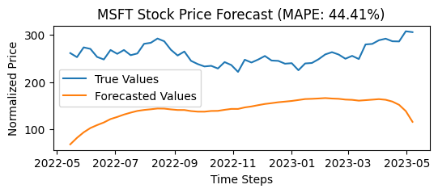

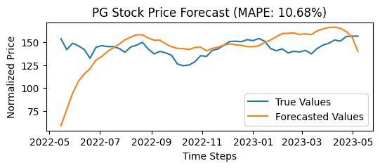

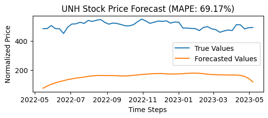

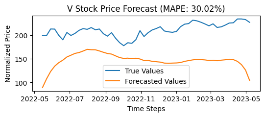

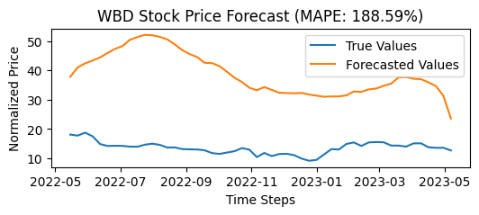

```python
# Loop through the dictionary and extract the forecasts for each series
for key in forecasts_2:
    # Extract the forecasted values for the current series
    forecast_values = forecasts_2[key][0, :, 0].flatten()
    # Extract the true values for the current series
    true_values = test_df[key]
    # Calculate the MAPE for the current series
    mape = mean_absolute_percentage_error(true_values, forecast_values)

    # Plot the forecasted values against the true values for the current series
    plt.figure(figsize=(6, 2))
    plt.plot(date_range, true_values, label='True Values')
    plt.plot(date_range, forecast_values, label='Forecasted Values')
    plt.title(f'{key} Stock Price Forecast (MAPE: {100*mape:.2f}%)')
    plt.xlabel('Time Steps')
    plt.ylabel('Normalized Price')
    plt.legend()
    plt.show()
```